# Austin_ML

2025-12-09

# 背景（Background）

- **作者（Author）**：Chengxiang Huang
- **建立日期（Created At）**：20251209
- **訓練資料路徑（Path to Training Data）：** /data/processed/austin.csv
- **測試資料路徑（Path to Testing Data）：** 無（本專案未切割測試集，模型評估依 10-fold Cross Validation）
- **模型規格（Model Specification）：**
  - **模型方法（Method）：**
    - 決策樹（Decision Tree, rpart via caret）
    - 隨機森林（Random Forest, randomForest via caret）
  - **變數（Variables）：**
    - **目標變數（Dependent Variable, Target）**：
      - los_index  
        （以各物種的中位數 LOS 切割：1 = 短等待時間，0 = 長等待時間）
    - **自變數（Independent Variables, Features）**：
      - sterilized（是否結紮）
      - sex（性別）
      - is_mixed（混種或純種）
      - color_type（毛色分類：Solid, Bicolor, Tricolor+, Patterned）
      - age_group（成年或幼年）
      - special_condition（是否具有特殊健康或行為狀況）
      - stray（來源：Owned 或 Stray）
  - **調參參數（Tuning Parameters）：**
    - **決策樹（Dog）**：
      - 最佳 cp：0.004
      - 最佳 minbucket：100
      - 最佳 maxdepth：3
    - **決策樹（Cat）**：
      - 最佳 cp：0.001
      - 最佳 minbucket：100
      - 最佳 maxdepth：10
    - **隨機森林（Dog）**：
      - ntree = 500
      - 最佳 mtry：6
    - **隨機森林（Cat）**：
      - ntree = 500
      - 最佳 mtry：2
  - **最佳化方法（Optimization Method）：**
    - 使用 Grid Search
    - 使用 10-fold Cross Validation
- **主要發現與結論（Main Findings and Takeaways）：**
  - 狗的模型：
    - 敏感度極高（非常容易預測成短等待時間）
    - 特異度低（較難辨識長等待動物）
  - 貓的模型：
    - 各項評估指標較平衡，因此表現略優於狗
  - 隨機森林顯示最重要的變數包含：
    - stray（是否為流浪）
    - special_condition（是否有特殊健康狀況）
    - age_group（成年或幼年）
    - sterilized（是否結紮）
  - **模型效能（In-sample Performance）**：

    **決策樹 — Dog**
    - Accuracy：**0.6046**
    - Recall：**0.9404**
    - F1-score：**0.7319**
    - AUC：**0.6196**

    **決策樹 — Cat**
    - Accuracy：**0.6388**
    - Recall：**0.5652**
    - F1-score：**0.6206**
    - AUC：**0.6468**

    **隨機森林 — Dog**
    - Accuracy：**0.6094**
    - Recall：**0.8897**
    - F1-score：**0.7233**
    - AUC：**0.6024**

    **隨機森林 — Cat**
    - Accuracy：**0.6406**
    - Recall：**0.5679**
    - F1-score：**0.6229**
    - AUC：**0.6646**
  - **整體觀察（Summary）**：
    - 模型準確度大致落在 0.60–0.64 間，屬中度分類性能
    - 貓模型比狗模型稍微穩定、平衡
    - 決策樹與隨機森林的表現差異不大
  - **樣本外效能（Out-sample Performance）：**
    - 無（本研究無外部測試資料）

```r
# Load packages here
library(tidyverse)
library(lubridate)
library(janitor)
library(rpart)
library(caret)
```

```r
library(rpart.plot)
library(randomForest)
library(pROC)
# Load the TRAINING data
austin <- read.csv("/Users/chengxianghuang/Downloads/austin.csv")
austin_clear <- austin %>%
  select(-c("Name", "Found.Location", "Sex.upon.Intake",
            "Date.of.Birth", "Outcome.Subtype", "Age.upon.Outcome")) %>%
  rename_with(tolower) %>%
  filter(animal.type %in% c("Cat", "Dog"), outcome.type == "Adoption") %>%
  mutate(animal.type = factor(animal.type, levels = c("Dog", "Cat"))) %>%
  rename(intake.datetime = intake_datetime,
         outcome.datetime = outcome_datetime) %>%
  mutate(start.date = ymd_hm(intake.datetime),
         end.date = ymd_hm(outcome.datetime),
         stay.day.round = round(as.numeric(difftime(end.date, start.date, units = "days")), 2),
         stay.day = floor(as.numeric(difftime(end.date, start.date, units = "days")))) %>%
  select(-c("outcome.type", "start.date", "end.date")) %>%
  mutate(
    sterilized = case_when(
      grepl("Neutered|Spayed", sex.upon.outcome, ignore.case = TRUE) ~ "Sterilized",
      grepl("Intact", sex.upon.outcome, ignore.case = TRUE) ~ "Intact",
      TRUE ~ "Unknown"
    ),
    sex = case_when(
      sex.upon.outcome == "Unknown" ~ "Unknown",
      TRUE ~ str_to_title(word(sex.upon.outcome, -1))
    ),
    sterilized = factor(sterilized, levels = c("Intact", "Sterilized", "Unknown")),
    sex = factor(sex, levels = c("Male", "Female", "Unknown"))
  ) %>%
  select(-sex.upon.outcome) %>%
  mutate(is_mixed = if_else(str_detect(breed, "Mix|/|-|&"), "Mixed", "Purebred"),
         is_mixed = factor(is_mixed, levels = c("Purebred", "Mixed"))) %>%
  mutate(
    color_type = case_when(
      str_detect(color, "(?i)Tabby|Brindle|Tortie|Calico|Merle|Point|Tick|Spotted|Speckled") ~ "Patterned",
      str_count(color, "/|&| ") == 0 ~ "Solid",
      str_count(color, "/|&| ") == 1 ~ "Bicolor",
      str_count(color, "/|&| ") >= 2 ~ "Tricolor+",
      TRUE ~ "Unknown"
    ),
    color_type = factor(color_type,
                        levels = c("Solid", "Bicolor", "Tricolor+", "Patterned"))
  ) %>%
  mutate(
    age_years = case_when(
      str_detect(age.upon.intake, "day")   ~ as.numeric(str_extract(age.upon.intake, "\\d+")) / 365,
      str_detect(age.upon.intake, "week")  ~ as.numeric(str_extract(age.upon.intake, "\\d+")) / 52,
      str_detect(age.upon.intake, "month") ~ as.numeric(str_extract(age.upon.intake, "\\d+")) / 12,
      str_detect(age.upon.intake, "year")  ~ as.numeric(str_extract(age.upon.intake, "\\d+")),
      TRUE ~ NA_real_
    ),
    age_group = case_when(
      age_years < 0.5 ~ "Juvenile",
      age_years >= 0.5 ~ "Adult",
      TRUE ~ NA_character_
    ),
    age_group = factor(age_group, levels = c("Adult", "Juvenile"))
  ) %>%
  select(-age_years) %>%
  mutate(
    special_condition = case_when(
      intake.condition %in% c("Injured","Sick","Medical","Nursing","Pregnant",
                              "Behavior","Feral", "Other") ~ "Special",
      TRUE ~ "Normal"
    ),
    special_condition = factor(special_condition, levels = c("Normal", "Special"))
  ) %>%
  filter(!intake.type %in% c("Public Assist", "Euthanasia Request")) %>%
  mutate(
    stray = case_when(
      intake.type == "Stray" ~ "Stray",
      intake.type %in% c("Abandoned", "Owner Surrender") ~ "Owned",
      TRUE ~ NA_character_
    ),
    stray = factor(stray, levels = c("Owned", "Stray"))
  ) %>%
  rename_with(~ str_replace_all(.x, "\\.", "_"))

# 4. Prepare for ML

austin_for_analysis <- austin_clear %>%
  mutate(log_stay_day_round = log1p(stay_day_round)) %>%
  filter(if_all(everything(), ~ !is.na(.))) %>%
  filter(
    if_all(where(is.factor),    ~ . != "Unknown") &
      if_all(where(is.character), ~ . != "Unknown")
  ) %>%
  mutate(
    sterilized = factor(sterilized, levels = c("Intact", "Sterilized")),
    sex = factor(sex, levels = c("Male", "Female")),
    color_type = factor(color_type, levels = c("Solid", "Bicolor", "Tricolor+", "Patterned")),
    age_group = factor(age_group, levels = c("Adult", "Juvenile")),
    special_condition = factor(special_condition, levels = c("Normal", "Special")),
    stray = factor(stray, levels = c("Owned", "Stray"))
  )

austin_for_analysis_dog <- austin_for_analysis %>% filter(animal_type == "Dog")
austin_for_analysis_cat <- austin_for_analysis %>% filter(animal_type == "Cat")


# LOS Calculations & Remove Outliers

los_all <- median(austin_for_analysis$stay_day_round, na.rm = TRUE)
los_dog <- median(austin_for_analysis_dog$stay_day_round, na.rm = TRUE)
los_cat <- median(austin_for_analysis_cat$stay_day_round, na.rm = TRUE)

Q1  <- quantile(austin_for_analysis$stay_day_round, 0.25)
Q3  <- quantile(austin_for_analysis$stay_day_round, 0.75)
upper <- Q3 + 1.5 * (Q3 - Q1)

Q1_dog  <- quantile(austin_for_analysis_dog$stay_day_round, 0.25)
Q3_dog  <- quantile(austin_for_analysis_dog$stay_day_round, 0.75)
upper_dog <- Q3_dog + 1.5 * (Q3_dog - Q1_dog)

Q1_cat  <- quantile(austin_for_analysis_cat$stay_day_round, 0.25)
Q3_cat  <- quantile(austin_for_analysis_cat$stay_day_round, 0.75)
upper_cat <- Q3_cat + 1.5 * (Q3_cat - Q1_cat)

austin_for_analysis_all <- austin_for_analysis %>%
  filter(stay_day_round <= upper) %>%
  mutate(los_index = as.integer(stay_day_round <= los_all))

austin_for_analysis_dog <- austin_for_analysis_dog %>%
  filter(stay_day_round <= upper_dog) %>%
  mutate(los_index = as.integer(stay_day_round <= los_dog))

austin_for_analysis_cat <- austin_for_analysis_cat %>%
  filter(stay_day_round <= upper_cat) %>%
  mutate(los_index = as.integer(stay_day_round <= los_cat))

# Print the first ten observations
head(austin_for_analysis_all, 10)
```

```
##    animal_id intake_datetime     intake_type intake_condition animal_type
## 1    A829964 2021/2/27 15:17           Stray           Normal         Dog
## 2    A828158  2021/1/8 19:01           Stray           Normal         Dog
## 3    A829611 2021/2/17 10:33 Owner Surrender          Injured         Cat
## 4    A828810 2021/1/26 16:14 Owner Surrender           Normal         Dog
## 5    A829949  2021/2/27 8:23           Stray           Normal         Dog
## 6    A829930 2021/2/26 15:17           Stray           Normal         Dog
## 7    A829868 2021/2/25 11:40           Stray           Normal         Dog
## 8    A829676 2021/2/20 17:10           Stray           Normal         Dog
## 9    A829776 2021/2/22 17:29 Owner Surrender           Normal         Dog
## 10   A829552 2021/2/13 11:43           Stray          Nursing         Dog
##    age_upon_intake                                              breed
## 1         3 months                                 Labrador Retriever
## 2        10 months                                     Rottweiler Mix
## 3          9 years                                 Domestic Shorthair
```

[output cut: 40 more lines]

```r
head(austin_for_analysis_dog, 10)
```

```
##    animal_id intake_datetime     intake_type intake_condition animal_type
## 1    A829964 2021/2/27 15:17           Stray           Normal         Dog
## 2    A828158  2021/1/8 19:01           Stray           Normal         Dog
## 3    A828810 2021/1/26 16:14 Owner Surrender           Normal         Dog
## 4    A829949  2021/2/27 8:23           Stray           Normal         Dog
## 5    A829930 2021/2/26 15:17           Stray           Normal         Dog
## 6    A829868 2021/2/25 11:40           Stray           Normal         Dog
## 7    A829676 2021/2/20 17:10           Stray           Normal         Dog
## 8    A829776 2021/2/22 17:29 Owner Surrender           Normal         Dog
## 9    A829552 2021/2/13 11:43           Stray          Nursing         Dog
## 10   A829483 2021/2/11 16:06           Stray           Normal         Dog
##    age_upon_intake                                              breed
## 1         3 months                                 Labrador Retriever
## 2        10 months                                     Rottweiler Mix
## 3        10 months Chihuahua Shorthair/American Staffordshire Terrier
```

[output cut: 40 more lines]

```r
head(austin_for_analysis_cat, 10)
```

```
##    animal_id intake_datetime     intake_type intake_condition animal_type
## 1    A829611 2021/2/17 10:33 Owner Surrender          Injured         Cat
## 2    A829816  2021/2/24 7:22           Stray          Injured         Cat
## 3    A828147  2021/1/8 16:26           Stray           Normal         Cat
## 4    A829516 2021/2/12 12:59           Stray           Normal         Cat
## 5    A829514 2021/2/12 12:59           Stray           Normal         Cat
## 6    A829513 2021/2/12 12:59           Stray           Normal         Cat
## 7    A825569 2020/11/6 12:21           Stray           Normal         Cat
## 8    A825126 2020/11/3 17:03           Stray           Normal         Cat
## 9    A828255 2021/1/12 10:59           Stray           Normal         Cat
## 10   A828254 2021/1/12 10:59           Stray           Normal         Cat
##    age_upon_intake                  breed              color outcome_datetime
## 1          9 years     Domestic Shorthair       Orange Tabby   2021/3/3 16:59
## 2           1 year   Domestic Medium Hair             Tortie   2021/3/2 17:44
## 3          1 month     Domestic Shorthair              Black   2021/3/2 13:25
```

[output cut: 29 more lines]

```r
# Include the model specification here.  Please describe the model by stating, including
# type of method used, the variables included, the hyperparameters, and
# the method of optimization.
```

本模型為一個二元分類模型，使用決策樹（rpart）與隨機森林（randomForest）方法。  
納入的變數包含：sterilized、sex、is_mixed、color_type、age_group、special_condition、stray。

#決策樹for dog

```r
vars <- c("sterilized", "sex", "is_mixed", "color_type",
          "age_group", "special_condition", "stray", "los_index")

df_dog_tree <- austin_for_analysis_dog[, vars]
df_dog_tree[] <- lapply(df_dog_tree, as.factor)

hyper_grid_dog <- expand.grid(
  cp = seq(0.001, 0.02, by = 0.003),
  minbucket = c(10, 20, 50, 100),
  maxdepth = c(3, 4, 5)
)

results_dog_tree <- tibble()

set.seed(123)
for (i in 1:nrow(hyper_grid_dog)) {
  cp_val <- hyper_grid_dog$cp[i]
  minbucket_val <- hyper_grid_dog$minbucket[i]
  maxdepth_val <- hyper_grid_dog$maxdepth[i]

  model <- train(
    los_index ~ .,
    data = df_dog_tree,
    method = "rpart",
    trControl = trainControl(method = "cv", number = 10),
    tuneGrid = data.frame(cp = cp_val),
    control = rpart.control(minbucket = minbucket_val, maxdepth = maxdepth_val)
  )

  results_dog_tree <- bind_rows(results_dog_tree, tibble(
    cp = cp_val, minbucket = minbucket_val, maxdepth = maxdepth_val,
    Accuracy = max(model$results$Accuracy),
    Model = list(model)
  ))
}

best_result_dog_tree <- results_dog_tree[which.max(results_dog_tree$Accuracy), ]
best_model_dog_tree <- best_result_dog_tree$Model[[1]]

cat("DOG — Best parameters:\n")
```

```
## DOG — Best parameters:
```

```r
print(best_result_dog_tree[, c("cp", "minbucket", "maxdepth", "Accuracy")])
```

```
## # A tibble: 1 × 4
##      cp minbucket maxdepth Accuracy
##   <dbl>     <dbl>    <dbl>    <dbl>
## 1 0.004       100        3    0.605
```

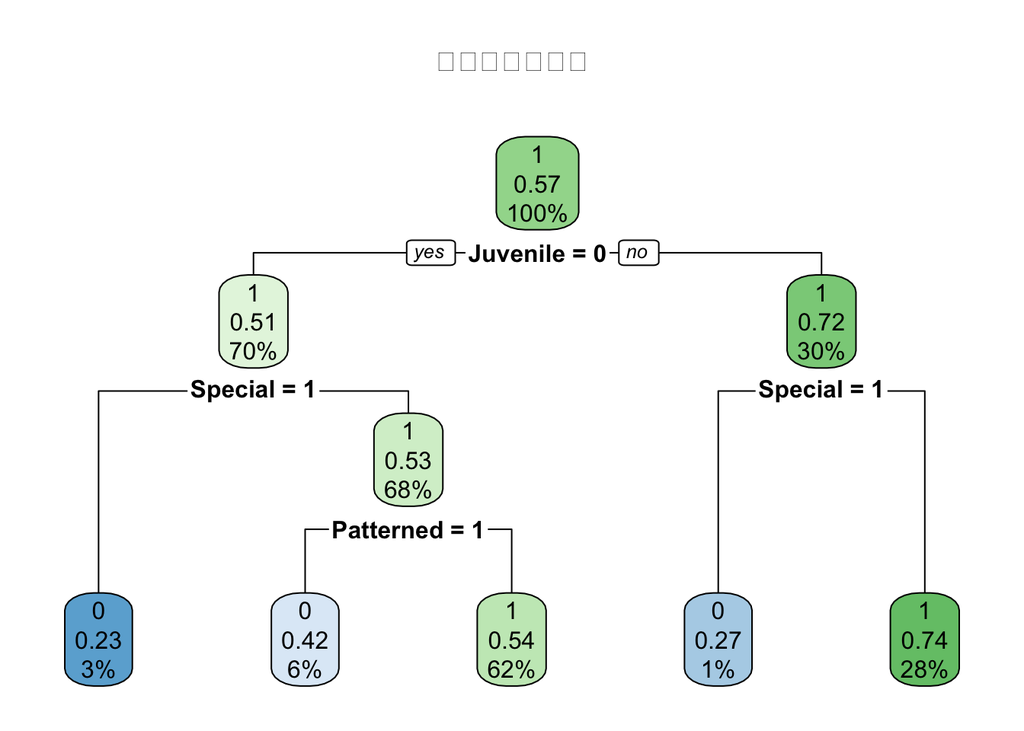

```r
rename_map <- c(
  "color_typePatterned"      = "Patterned",
  "color_typeBicolor"        = "Bicolor",
  "color_typeTricolor+"      = "Tricolor+",
  "sexFemale"                = "Female",
  "is_mixedMixed"            = "Mixed",
  "special_conditionSpecial" = "Special",
  "sterilizedSterilized"     = "Sterilized",
  "age_groupJuvenile"        = "Juvenile",
  "strayStray"               = "Stray"
)

best_model_dog_tree$finalModel$frame$var <- ifelse(
  best_model_dog_tree$finalModel$frame$var %in% names(rename_map),
  rename_map[best_model_dog_tree$finalModel$frame$var],
  best_model_dog_tree$finalModel$frame$var
)

rpart.plot(best_model_dog_tree$finalModel, main = "狗子最佳決策樹")
```

```r
pred_dog_tree <- predict(best_model_dog_tree, newdata = df_dog_tree)
confusionMatrix(pred_dog_tree, df_dog_tree$los_index)
```

```
## Confusion Matrix and Statistics
##
##           Reference
## Prediction     0     1
##          0  1826   961
##          1 10150 15164
##
##                Accuracy : 0.6046
##                  95% CI : (0.5989, 0.6103)
##     No Information Rate : 0.5738
##     P-Value [Acc > NIR] : < 2.2e-16
##
##                   Kappa : 0.103
##
##  Mcnemar's Test P-Value : < 2.2e-16
##
##             Sensitivity : 0.15247
##             Specificity : 0.94040
##          Pos Pred Value : 0.65518
##          Neg Pred Value : 0.59904
##              Prevalence : 0.42618
##          Detection Rate : 0.06498
##    Detection Prevalence : 0.09918
##       Balanced Accuracy : 0.54644
##
##        'Positive' Class : 0
##
```

#決策樹 for cat

```r
df_cat_tree <- austin_for_analysis_cat[, vars]
df_cat_tree[] <- lapply(df_cat_tree, as.factor)

hyper_grid_cat <- expand.grid(
  cp = seq(0.001, 0.02, by = 0.003),
  minbucket = c(10, 20, 50, 100),
  maxdepth = c(3, 5, 7, 10)
)

results_cat_tree <- tibble()

set.seed(123)
for (i in 1:nrow(hyper_grid_cat)) {
  cp_val <- hyper_grid_cat$cp[i]
  minbucket_val <- hyper_grid_cat$minbucket[i]
  maxdepth_val <- hyper_grid_cat$maxdepth[i]

  model <- train(
    los_index ~ .,
    data = df_cat_tree,
    method = "rpart",
    trControl = trainControl(method = "cv", number = 10),
    tuneGrid = data.frame(cp = cp_val),
    control = rpart.control(minbucket = minbucket_val, maxdepth = maxdepth_val)
  )

  results_cat_tree <- bind_rows(results_cat_tree, tibble(
    cp = cp_val, minbucket = minbucket_val, maxdepth = maxdepth_val,
    Accuracy = max(model$results$Accuracy),
    Model = list(model)
  ))
}

best_result_cat_tree <- results_cat_tree[which.max(results_cat_tree$Accuracy), ]
best_model_cat_tree <- best_result_cat_tree$Model[[1]]

cat("CAT — Best parameters:\n")
```

```
## CAT — Best parameters:
```

```r
print(best_result_cat_tree[, c("cp", "minbucket", "maxdepth", "Accuracy")])
```

```
## # A tibble: 1 × 4
##      cp minbucket maxdepth Accuracy
##   <dbl>     <dbl>    <dbl>    <dbl>
## 1 0.001       100       10    0.639
```

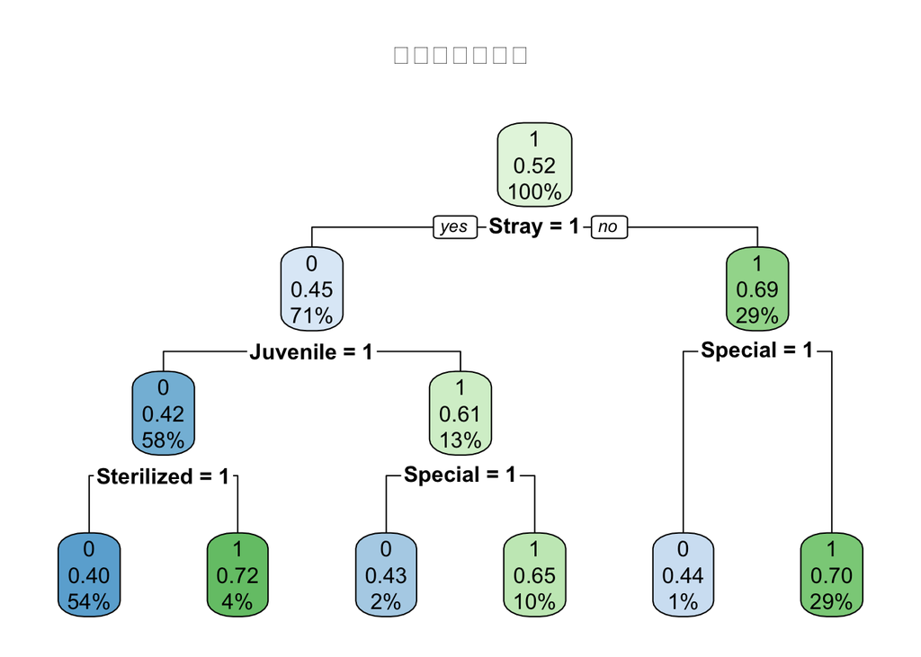

```r
rename_map <- c(
  "color_typePatterned"      = "Patterned",
  "color_typeBicolor"        = "Bicolor",
  "color_typeTricolor+"      = "Tricolor+",
  "sexFemale"                = "Female",
  "is_mixedMixed"            = "Mixed",
  "special_conditionSpecial" = "Special",
  "sterilizedSterilized"     = "Sterilized",
  "age_groupJuvenile"        = "Juvenile",
  "strayStray"               = "Stray"
)

best_model_cat_tree$finalModel$frame$var <- ifelse(
  best_model_cat_tree$finalModel$frame$var %in% names(rename_map),
  rename_map[best_model_cat_tree$finalModel$frame$var],
  best_model_cat_tree$finalModel$frame$var
)

rpart.plot(best_model_cat_tree$finalModel, main = "貓咪最佳決策樹")
```

```r
pred_cat_tree <- predict(best_model_cat_tree, newdata = df_cat_tree)
confusionMatrix(pred_cat_tree, df_cat_tree$los_index)
```

```
## Confusion Matrix and Statistics
##
##           Reference
## Prediction    0    1
##          0 6827 4520
##          1 2663 5876
##
##                Accuracy : 0.6388
##                  95% CI : (0.6321, 0.6455)
##     No Information Rate : 0.5228
##     P-Value [Acc > NIR] : < 2.2e-16
##
##                   Kappa : 0.2822
##
##  Mcnemar's Test P-Value : < 2.2e-16
##
##             Sensitivity : 0.7194
##             Specificity : 0.5652
##          Pos Pred Value : 0.6017
##          Neg Pred Value : 0.6881
##              Prevalence : 0.4772
##          Detection Rate : 0.3433
##    Detection Prevalence : 0.5706
##       Balanced Accuracy : 0.6423
##
##        'Positive' Class : 0
##
```

#隨機森林 for cat

```r
vars_rf <- c("stray", "special_condition", "age_group", "is_mixed",
             "sex", "color_type", "sterilized", "los_index")

df_cat_rf <- austin_for_analysis_cat[, vars_rf]
df_cat_rf[] <- lapply(df_cat_rf, as.factor)

set.seed(123)
ctrl <- trainControl(method = "cv", number = 10)
mtry_range <- expand.grid(mtry = 2:(ncol(df_cat_rf) - 1))

rf_model_cat <- train(
  los_index ~ .,
  data = df_cat_rf,
  method = "rf",
  trControl = ctrl,
  tuneGrid = mtry_range,
  importance = TRUE,
  ntree = 500
)

print(rf_model_cat)
```

```
## Random Forest
##
## 19886 samples
##     7 predictor
##     2 classes: '0', '1'
##
## No pre-processing
## Resampling: Cross-Validated (10 fold)
## Summary of sample sizes: 17897, 17898, 17897, 17897, 17897, 17897, ...
## Resampling results across tuning parameters:
##
##   mtry  Accuracy   Kappa
##   2     0.6398455  0.2841981
##   3     0.6393427  0.2831143
##   4     0.6390411  0.2824243
##   5     0.6388902  0.2820680
##   6     0.6383371  0.2810047
##   7     0.6381862  0.2807479
##
## Accuracy was used to select the optimal model using the largest value.
## The final value used for the model was mtry = 2.
```

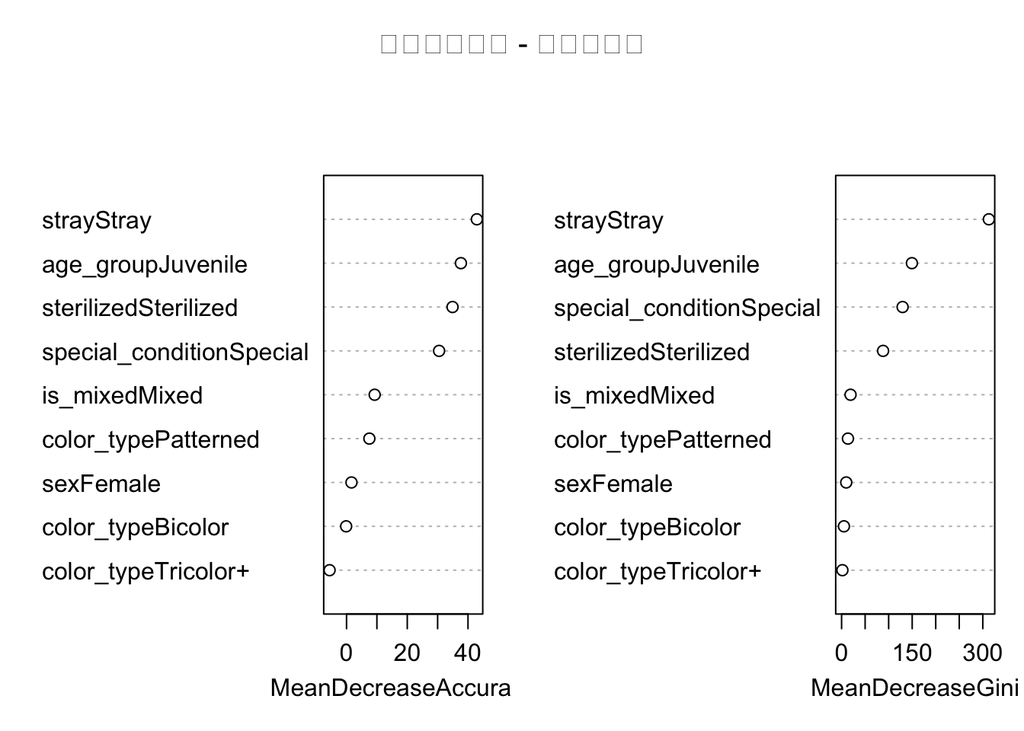

```r
varImpPlot(rf_model_cat$finalModel, main = "貓咪隨機森林 - 變數重要性")
```

```r
pred_cat_rf <- predict(rf_model_cat, newdata = df_cat_rf)
confusionMatrix(pred_cat_rf, df_cat_rf$los_index)
```

```
## Confusion Matrix and Statistics
##
##           Reference
## Prediction    0    1
##          0 6834 4492
##          1 2656 5904
##
##                Accuracy : 0.6406
##                  95% CI : (0.6338, 0.6472)
##     No Information Rate : 0.5228
##     P-Value [Acc > NIR] : < 2.2e-16
##
##                   Kappa : 0.2856
##
##  Mcnemar's Test P-Value : < 2.2e-16
##
##             Sensitivity : 0.7201
##             Specificity : 0.5679
##          Pos Pred Value : 0.6034
##          Neg Pred Value : 0.6897
##              Prevalence : 0.4772
##          Detection Rate : 0.3437
##    Detection Prevalence : 0.5695
##       Balanced Accuracy : 0.6440
##
##        'Positive' Class : 0
##
```

#隨機森林 for dog

```r
vars_rf <- c("stray", "special_condition", "age_group", "is_mixed",
             "sex", "color_type", "sterilized", "los_index")

df_dog_rf <- austin_for_analysis_dog[, vars_rf]
df_dog_rf[] <- lapply(df_dog_rf, as.factor)

set.seed(123)
mtry_range <- expand.grid(mtry = 2:(ncol(df_dog_rf) - 1))

rf_model_dog <- train(
  los_index ~ .,
  data = df_dog_rf,
  method = "rf",
  trControl = ctrl,
  tuneGrid = mtry_range,
  importance = TRUE,
  ntree = 500
)

print(rf_model_dog)
```

```
## Random Forest
##
## 28101 samples
##     7 predictor
##     2 classes: '0', '1'
##
## No pre-processing
## Resampling: Cross-Validated (10 fold)
## Summary of sample sizes: 25291, 25290, 25291, 25291, 25291, 25291, ...
## Resampling results across tuning parameters:
##
##   mtry  Accuracy   Kappa
##   2     0.6043550  0.1007624
##   3     0.6045687  0.1029560
##   4     0.6043196  0.1164192
##   5     0.6042841  0.1188314
##   6     0.6059211  0.1247907
##   7     0.6054229  0.1237885
##
## Accuracy was used to select the optimal model using the largest value.
## The final value used for the model was mtry = 6.
```

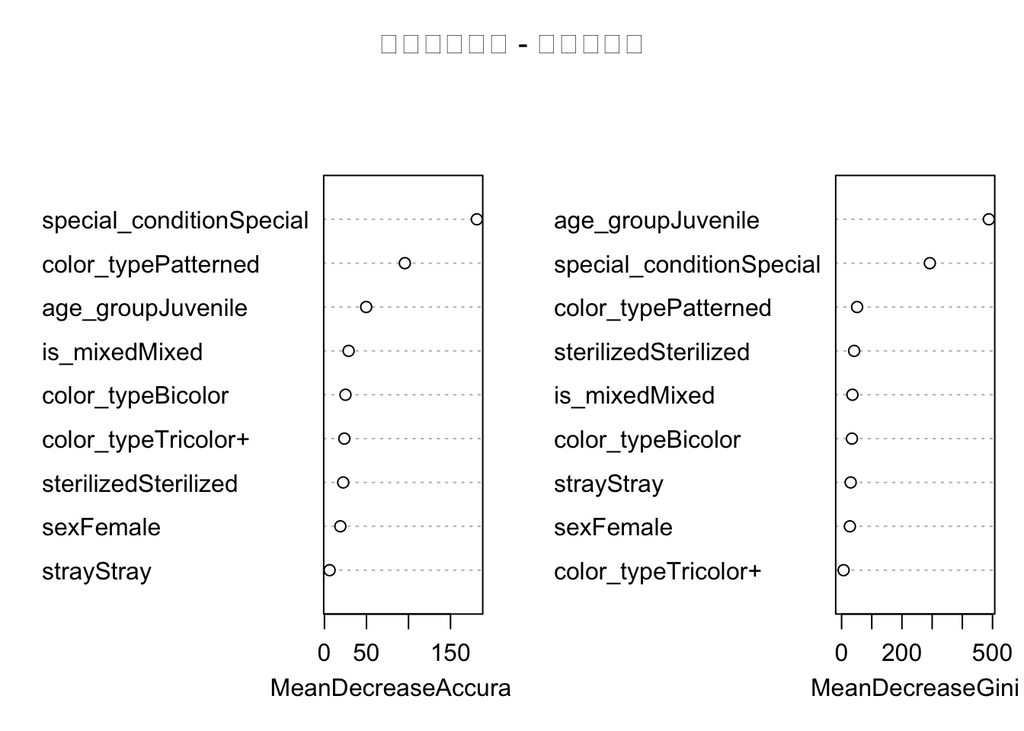

```r
varImpPlot(rf_model_dog$finalModel, main = "狗子隨機森林 - 變數重要性")
```

```r
pred_dog_rf <- predict(rf_model_dog, newdata = df_dog_rf)
confusionMatrix(pred_dog_rf, df_dog_rf$los_index)
```

```
## Confusion Matrix and Statistics
##
##           Reference
## Prediction     0     1
##          0  2780  1779
##          1  9196 14346
##
##                Accuracy : 0.6094
##                  95% CI : (0.6037, 0.6152)
##     No Information Rate : 0.5738
##     P-Value [Acc > NIR] : < 2.2e-16
##
##                   Kappa : 0.1324
##
##  Mcnemar's Test P-Value : < 2.2e-16
##
##             Sensitivity : 0.23213
##             Specificity : 0.88967
##          Pos Pred Value : 0.60978
##          Neg Pred Value : 0.60938
##              Prevalence : 0.42618
##          Detection Rate : 0.09893
##    Detection Prevalence : 0.16224
##       Balanced Accuracy : 0.56090
##
##        'Positive' Class : 0
##
```

```r
compute_metrics <- function(model, data, target_var) {

  data[[target_var]] <- factor(data[[target_var]], levels = c("1", "0"))

  pred_class <- predict(model, newdata = data)


  pred_class <- factor(pred_class, levels = c("1", "0"))

  pred_prob <- predict(model, newdata = data, type = "prob")[, 2]

  cm <- confusionMatrix(pred_class, data[[target_var]], positive = "1")

  accuracy <- cm$overall["Accuracy"]
  recall   <- cm$byClass["Sensitivity"]
  f1       <- cm$byClass["F1"]

  roc_obj <- roc(data[[target_var]], pred_prob, levels = c("0", "1"), direction = "<")
  auc_val <- auc(roc_obj)

  list(
    ConfusionMatrix = cm,
    Accuracy = accuracy,
    Recall = recall,
    F1 = f1,
    AUC = auc_val
  )
}


print_model_result <- function(name, metrics) {
  cat("\n============================================================\n")
  cat(paste(" Performance Metrics —", name, "\n"))
  cat("============================================================\n")
  print(metrics$ConfusionMatrix)
  cat("\nAccuracy:", round(metrics$Accuracy, 4), "\n")
  cat("Recall:", round(metrics$Recall, 4), "\n")
  cat("F1-score:", round(metrics$F1, 4), "\n")
  cat("AUC:", round(metrics$AUC, 4), "\n")
}



metrics_dog_tree <- compute_metrics(best_model_dog_tree, df_dog_tree, "los_index")
metrics_cat_tree <- compute_metrics(best_model_cat_tree, df_cat_tree, "los_index")
metrics_dog_rf   <- compute_metrics(rf_model_dog,       df_dog_rf,   "los_index")
metrics_cat_rf   <- compute_metrics(rf_model_cat,       df_cat_rf,   "los_index")


print_model_result("Dog — Decision Tree", metrics_dog_tree)
```

```
##
## ============================================================
##  Performance Metrics — Dog — Decision Tree
## ============================================================
## Confusion Matrix and Statistics
##
##           Reference
## Prediction     1     0
##          1 15164 10150
##          0   961  1826
##
##                Accuracy : 0.6046
##                  95% CI : (0.5989, 0.6103)
##     No Information Rate : 0.5738
##     P-Value [Acc > NIR] : < 2.2e-16
##
##                   Kappa : 0.103
##
##  Mcnemar's Test P-Value : < 2.2e-16
##
##             Sensitivity : 0.9404
##             Specificity : 0.1525
##          Pos Pred Value : 0.5990
##          Neg Pred Value : 0.6552
##              Prevalence : 0.5738
##          Detection Rate : 0.5396
##    Detection Prevalence : 0.9008
##       Balanced Accuracy : 0.5464
##
##        'Positive' Class : 1
##
##
## Accuracy: 0.6046
## Recall: 0.9404
## F1-score: 0.7319
## AUC: 0.6196
```

```r
print_model_result("Cat — Decision Tree", metrics_cat_tree)
```

```
##
## ============================================================
##  Performance Metrics — Cat — Decision Tree
## ============================================================
## Confusion Matrix and Statistics
##
##           Reference
## Prediction    1    0
##          1 5876 2663
##          0 4520 6827
##
##                Accuracy : 0.6388
##                  95% CI : (0.6321, 0.6455)
##     No Information Rate : 0.5228
##     P-Value [Acc > NIR] : < 2.2e-16
##
##                   Kappa : 0.2822
##
##  Mcnemar's Test P-Value : < 2.2e-16
##
##             Sensitivity : 0.5652
##             Specificity : 0.7194
##          Pos Pred Value : 0.6881
##          Neg Pred Value : 0.6017
##              Prevalence : 0.5228
##          Detection Rate : 0.2955
##    Detection Prevalence : 0.4294
##       Balanced Accuracy : 0.6423
##
##        'Positive' Class : 1
##
##
## Accuracy: 0.6388
## Recall: 0.5652
## F1-score: 0.6206
## AUC: 0.6468
```

```r
print_model_result("Dog — Random Forest", metrics_dog_rf)
```

```
##
## ============================================================
##  Performance Metrics — Dog — Random Forest
## ============================================================
## Confusion Matrix and Statistics
##
##           Reference
## Prediction     1     0
##          1 14346  9196
##          0  1779  2780
##
##                Accuracy : 0.6094
##                  95% CI : (0.6037, 0.6152)
##     No Information Rate : 0.5738
##     P-Value [Acc > NIR] : < 2.2e-16
##
##                   Kappa : 0.1324
##
##  Mcnemar's Test P-Value : < 2.2e-16
##
##             Sensitivity : 0.8897
##             Specificity : 0.2321
##          Pos Pred Value : 0.6094
##          Neg Pred Value : 0.6098
##              Prevalence : 0.5738
##          Detection Rate : 0.5105
##    Detection Prevalence : 0.8378
##       Balanced Accuracy : 0.5609
##
##        'Positive' Class : 1
##
##
## Accuracy: 0.6094
## Recall: 0.8897
## F1-score: 0.7233
## AUC: 0.6024
```

```r
print_model_result("Cat — Random Forest", metrics_cat_rf)
```

```
##
## ============================================================
##  Performance Metrics — Cat — Random Forest
## ============================================================
## Confusion Matrix and Statistics
##
##           Reference
## Prediction    1    0
##          1 5904 2656
##          0 4492 6834
##
##                Accuracy : 0.6406
##                  95% CI : (0.6338, 0.6472)
##     No Information Rate : 0.5228
##     P-Value [Acc > NIR] : < 2.2e-16
##
##                   Kappa : 0.2856
##
##  Mcnemar's Test P-Value : < 2.2e-16
##
##             Sensitivity : 0.5679
##             Specificity : 0.7201
##          Pos Pred Value : 0.6897
##          Neg Pred Value : 0.6034
##              Prevalence : 0.5228
##          Detection Rate : 0.2969
##    Detection Prevalence : 0.4305
##       Balanced Accuracy : 0.6440
##
##        'Positive' Class : 1
##
##
## Accuracy: 0.6406
## Recall: 0.5679
## F1-score: 0.6229
## AUC: 0.6646
```